# Introduction to Digital Forensics for cybercrime

#### Assignment 2

**Group 5**  
Fatema Alammal s2058502  
Ellen Wittingen s2095610  
Anniek Megens s1982869  
Jelte van Bommel s2136074  
Denis Arva s2188511  
Joel Tyhaar s2138603

## Motivation and Goals

A Denial of Service (DoS) attack involves sabotaging the use of a service offered online by making it unavailable for its intended users. A more powerful variation of a DoS attack is a Distributed Denial of Service attack, in which multiple systems participate in overwhelming the machine responsible for the service provided (Keary, 2020). Such a seemingly harmless attack becomes more fatal for certain organisations, which may as a result, contact the police or another organisation intended for dealing with cybersecurity threats.

DDoS attacks, as many other cyberattacks can be difficult to deal with. Investigation and analysis must go into the case by means of digital forensics to understand what happened and to trace back the source of the attack. One of these DDoS attacks had to be investigated by Jair Santanna, while working for the Dutch Team High Tech (DTHT) police. This report covers an analysis of the data collected from the attack. The methodology and results of the analysis will be presented, along with a reflection on the findings and what is concluded from this incident. The aim of this research is to discover how this DDoS attack took place and what could be done to prevent such an attack.

[Keary, T. (2020, July 14). DoS vs DDoS attacks: The Differences and How To Prevent Them. Retrieved October 6, 2020, from https://www.comparitech.com/net-admin/dos-vs-ddos-attacks-differences-prevention/](https://www.comparitech.com/net-admin/dos-vs-ddos-attacks-differences-prevention/)

## Methodology and Results

### Exporting the network trace

A capture of network traffic was provided to us by Jair Santanna. This file is too large to upload to a Git repository, so has not been added. This packet capture file (real_booter_attack.pcap) can be opened with the well-known analysis tool Wireshark:

[figure not shown]

While Wireshark provides plenty of analysis options. We would like to analyse this network trace using the tools we are familiar with: Pandas, Numpy and Matplotlib. In order to do so we first need to export the capture into a format we can read into Pandas: a CSV file. This export will only contain the columns that are currently visible in the Wireshark window. Without any configuration, this is a very small amount of the available information. We add additional columns by rightclicking the headers and clicking 'Column Preferences':

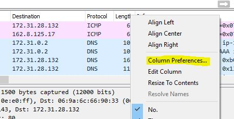

The columns that are selected depend on the type of analysis you want to conduct. For this analysis the following columns have been chosen:

[figure not shown]

One can now export these columns from the Wireshark Window to a CSV by going to the 'File' menu and choosing 'Export Packet Dissections' > '... As CSV':

[figure not shown]

### Loading Pandas

We will now import the required libraries and load this exported CSV into a pandas dataframe to begin our analysis.

```python
import pandas as pd
import numpy as np
import matplotlib.pyplot as plt
import math

# Display options
pd.options.display.max_rows = None
pd.options.display.max_columns = None

# Read the CSV file
df = pd.read_csv('ddos_data.csv')
df.head()
```

|  | No. | Time | Source | Destination | Protocol | Length | Info | Hardwaresrcaddr | Hardwaredestaddr | Destinationport | Sourceport | Name | Flags |
| --- | --- | --- | --- | --- | --- | --- | --- | --- | --- | --- | --- | --- | --- |
| 0 | 1 | 0.000000 | 162.8.125.17 | 172.31.28.132 | ICMP | 62 | Echo (ping) request id=0x07ae, seq=33434/3955... | 06:90:f4:0e:e0:ff | 06:9a:6c:66:90:33 | NaN | NaN | NaN | NaN |
| 1 | 2 | 0.000037 | 172.31.28.132 | 162.8.125.17 | ICMP | 62 | Echo (ping) reply id=0x07ae, seq=33434/3955... | 06:9a:6c:66:90:33 | 06:90:f4:0e:e0:ff | NaN | NaN | NaN | NaN |
| 2 | 3 | 0.122451 | 172.31.28.132 | 172.31.0.2 | DNS | 103 | Standard query 0x1365 A ip-172-31-28-132.us-we... | 06:9a:6c:66:90:33 | 06:90:f4:0e:e0:ff | 53.0 | 51139.0 | ip-172-31-28-132.us-west-2.compute.internal | 0x0100 |
| 3 | 4 | 0.122477 | 172.31.28.132 | 172.31.0.2 | DNS | 103 | Standard query 0xb0d5 AAAA ip-172-31-28-132.us... | 06:9a:6c:66:90:33 | 06:90:f4:0e:e0:ff | 53.0 | 51139.0 | ip-172-31-28-132.us-west-2.compute.internal | 0x0100 |
| 4 | 5 | 0.122684 | 172.31.0.2 | 172.31.28.132 | DNS | 164 | Standard query response 0xb0d5 AAAA ip-172-31-... | 06:90:f4:0e:e0:ff | 06:9a:6c:66:90:33 | 51139.0 | 53.0 | ip-172-31-28-132.us-west-2.compute.internal | 0x8180 |

### Amount of records in the trace (Q1)

To verify that all packets that were in the trace when opened in Wireshark, are also in this dataset, the packet count in Wireshark is compared to the amount of rows in the dataframe.

```python
df.shape[0]
```

```
122233
```

This dataset contains 122233 packets, this is identical to the count in Wireshark, confirming that this dataset contains all packets.

### Duration of the entire trace (Q2)

```python
df.Time.max()
```

```
25.343013
```

The dataset contains the packets captured during a little more than 25 seconds.

### Packets that are not part of the attack (Q3)

However, upon initial inspection in Wireshark it seems that this dataset contains packets that do not belong to the attack, such as the following:

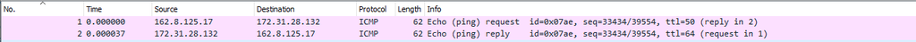

[figure not shown]

These are ping packets. A ping packet is basically a packet sent by a host to the server to see if the server is up. The server then sends a reply back to the host that requested it, so they know the server is up.

This is a UDP (User Datagram Protocol) package. There is only one of these loose UDP packages in the entire trace, so we think it is not part of the attack. UDP is part of the transport layer and does not ensure that the package reaches the destination, as it does not use handshakes or anything else to ensure the sender that the receiver received it.

### Fingerprint of the attack (Q4 + Q6 + Q13)

Since we want to look at the attack traffic and exclude other traffic, we want to create a fingerprint of the attack. Using this fingerprint we can then identify which traffic belongs to the attack traffic and which traffic is regular/other traffic. To fingerprint the attack we first look at all of the destination IP addresses of the attack. We do this by plotting the IP addresses that are occurring as a destination in a graph.

#### Target IP of the attack (Q6)

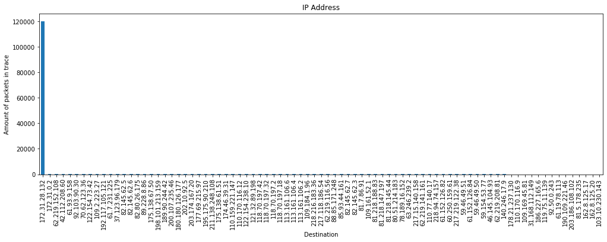

```python
plot = df.groupby('Destination').count()["No."].sort_values(ascending=False).plot(kind='bar', title="IP Address", figsize=(17, 5))
plot.set_ylabel("Amount of packets in trace")
```

We can see that the most packets in the attack trace are directed at the IP address: 172.31.28.132. Since this is the server that receives the most packets, we assume this is the target IP of the DDoS attack.

#### Sources of the packets

In order to see if there is a specific fingerprint, we check if there is a small set of IP addresses that are messaging the target IP address.

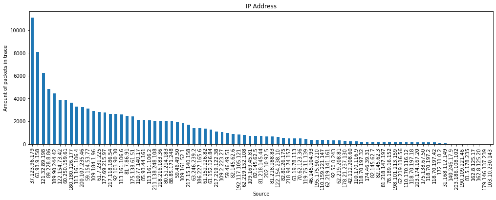

```python
traffic_to_victim = df[df.Destination == "172.31.28.132"]
plot = traffic_to_victim.groupby('Source').count()["No."].sort_values(ascending=False).plot(kind='bar', title="IP Address", figsize=(17, 5))
plot.set_ylabel("Amount of packets in trace")
```

#### Destination ports of the attack

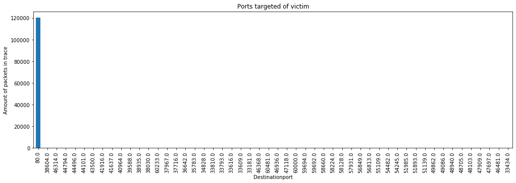

```python
plot = traffic_to_victim.groupby('Destinationport').count()["No."].sort_values(ascending=False).plot(kind='bar', title="Ports targeted of victim", figsize=(17, 5))
plot.set_ylabel("Amount of packets in trace")
```

There are different ports being targeted. The main focus of the attack however appears to be port 80. The packets targeting this port appear to orginate from the following source ports:

#### Source ports of the attack (Q13)

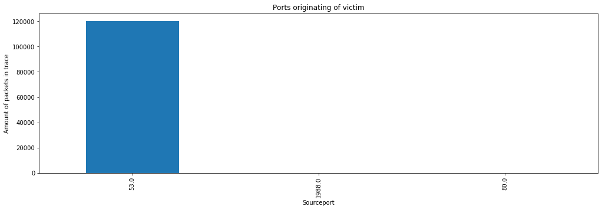

```python
plot = traffic_to_victim.groupby('Sourceport').count()["No."].sort_values(ascending=False).plot(kind='bar', title="Ports originating of victim", figsize=(17, 5))
plot.set_ylabel("Amount of packets in trace")
```

The most repeating source port in the attack is port 53. Therefore we can conclude that the source port used in the attack is port 53. This port is used in the DNS protocol.

#### DNS amplification

The ports are giving us a better understanding of what is happening here. Since port 80 is used for webservers and port 53 is used for DNS servers. It appears that a webserver is targeted with many traffic coming from a DNS server. This is a phenomenon that appears when a DNS amplification attack is performed. DNS works on the UDP protocol. The attacker sends packets with a spoofed IP address to a DNS server. These packets are requests for the DNS server to resolve a certain query, often chosen to have a response as big as possible. The spoofed IP address in the request is the IP address of the victim. The DNS server responds to the query by sending a response to the IP address, which is in this case the victim. By making a small query, a large response can be sent to the victim (amplification), essentially overloading their resources at some point.

At this point we have a fingerprint candidate for this DDoS attack: the source port of the packet is port 53, the destination port 80. However theoretically there could still be legitimate packets in this criteria. Therefore we analyze the DNS requests a bit further, by inspecting the requested domainnames in the trace.

```python
print("Packets in the trace before filtering on source and dest port: {}".format(traffic_to_victim.shape[0]))
traffic_to_victim_filtered = traffic_to_victim[(traffic_to_victim.Sourceport == 53) & (traffic_to_victim.Destinationport == 80)]
print("Packets in the trace after filtering on source and dest port: {}".format(traffic_to_victim_filtered.shape[0]))
```

```
Packets in the trace before filtering on source and dest port: 120253
Packets in the trace after filtering on source and dest port: 120149
```

#### Requested Domain Names

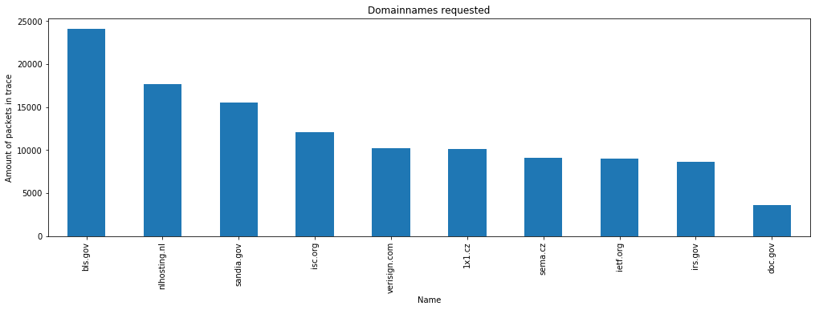

```python
plot = traffic_to_victim_filtered.groupby('Name').count()["No."].sort_values(ascending=False).plot(kind='bar', title="Domainnames requested", figsize=(17, 5))
plot.set_ylabel("Amount of packets in trace")
```

There are 10 unique domainnames that are requested in the attack, each one with a relatively large amount of packets that it does not appear that this could be legitimate within the timespan of the trace.

#### Concluding fingerprint

So the fingerprint of the attack are the characteristics that most repeats in the trace, which in this case are the packets sent to the (victim) IP 172.31.28.132 originating from port 53 and targeting port 80. The 10 domainnames ('nlhosting.nl', 'isc.org', 'sandia.gov', 'bls.gov', 'sema.cz', 'ietf.org', 'verisign.com', '1x1.cz', 'irs.gov', 'doc.gov') that are frequently requested in the attack can be part of the fingerprint to make the fingerprint more specific (and prevent legitimate traffic from being blocked, in case the fingerprint is used for blocking attacks).

### Wireshark filter of the attack (Q5)

Now that we know the fingerprint of the attack, we can use this fingerprint to filter the attack traffic from the legitimate traffic in the trace. A Wireshark filter for this attack would be: (!icmp is added since Wireshark does include ICMP packets that encapsulate a packet that fits the criteria. These are copies of the packets that came in and do not interest us since they are thus already included in the dataset.)

```
ip.dst == 172.31.28.132 && udp.srcport == 53 && udp.dstport==80 && !icmp
```

If we want to filter based on the domainnames requested, we could use

```
!icmp && dns.qry.name == "verisign.com" || dns.qry.name == "nlhosting.nl" || dns.qry.name == "sema.cz" || dns.qry.name== "irs.gov" || dns.qry.name == "1x1.cz" || dns.qry.name == "sandia.gov" || dns.qry.name == "ietf.org"  || dns.qry.name == "doc.gov" || dns.qry.name == "bls.gov" || dns.qry.name == "isc.org"
```

Ideally if this is used to filter traffic, one would combine these filters to make them more specific in order to allow as much legitimate traffic to continue. However attackers can adapt the domainnames requested, so this requires an active approach in discovering new domainnames that are used for the amplification attack

### Amount of records belonging to the attack (Q7)

Now that we can isolate the attack traffic, we can analyze this attack traffic in further depth.

```python
traffic_to_victim_filtered.shape[0]
```

```
120149
```

There are 120149 records that belong to the attack traffic.

### Unique source IP addresses (Q8)

```python
traffic_to_victim_filtered.Source.unique()
```

```
array(['89.228.8.86', '70.62.123.36', '82.145.62.6', '82.145.62.5',
       '37.123.96.179', '92.103.90.30', '82.80.26.175', '192.117.105.121',
       '61.93.9.158', '81.5.178.235', '198.101.213.159', '218.216.183.36',
       '62.219.152.108', '109.2.223.27', '81.218.145.44', '61.7.231.225',
       '122.154.73.42', '42.112.208.60', '61.19.78.113', '122.154.238.10',
       '81.218.188.83', '121.32.89.198', '59.154.53.77', '203.174.167.20',
       '82.145.62.7', '82.145.62.3', '211.138.248.108', '110.170.116.9',
       '81.7.86.91', '110.170.116.12', '60.250.159.61', '109.184.1.96',
       '217.15.140.158', '200.107.235.46', '113.161.106.4',
       '62.219.141.161', '61.152.126.84', '202.10.92.5',
       '180.180.126.177', '109.161.52.1', '217.118.186.54',
       '189.90.244.42', '80.51.214.183', '85.93.44.161', '88.85.171.248',
       '110.159.221.147', '59.46.49.50', '63.246.239.2', '61.152.126.82',
       '113.161.106.6', '46.145.104.93', '195.175.90.210',
       '110.77.140.17', '177.69.215.97', '118.70.197.18', '175.138.61.51',
       '118.70.197.32', '113.161.106.2', '218.94.74.157', '118.70.197.42',
       '217.219.122.38', '59.46.49.51', '174.46.39.31', '175.138.67.50',
       '81.218.147.197', '62.219.116.56', '118.70.197.2', '78.189.16.152',
       '140.246.17.9', '62.219.208.81', '190.109.221.46', '119.75.11.139',
       '178.21.237.130', '186.227.165.6', '109.169.45.81',
       '31.168.112.149', '92.50.0.243', '103.10.230.143',
       '203.186.108.102'], dtype=object)
```

There however appear quite a few unique IP addresses as the source of packets in the attack traffic. In total 79 unique IP addresses. Not all of these IP addresses contribute as much packets to the attack traffic as others. One could define criteria to exclude certain IP addresses due to the fact that they have not sent as much packets. However, for our analysis we opted to include all of these IP addresses, since still *many little ones make a great one*.

#### Top 3 IP's (Q9)

We can see the difference in how much each IP address contributed to the total amount of packets by looking at the Top 3 IP's that sent the most packets and the 3 that sent the least packets.

```python
traffic_to_victim_filtered.groupby("Source")["No."].count().sort_values(ascending=False)[:3]
```

```
Source
37.123.96.179    11126
61.93.9.158       8086
121.32.89.198     6261
Name: No., dtype: int64
```

```python
traffic_to_victim_filtered.groupby("Source")["No."].count().sort_values(ascending=True)[:3]
```

```
Source
103.10.230.143     1
81.5.178.235       5
190.109.221.46    10
Name: No., dtype: int64
```

As we can see there are certain IP addresses that sent thousands of packets, but also IP addresses that sent just a few packets. This might be due to the fact that these were slow DNS servers and the attacker opted to use ones that could send packets faster, but another option is that these DNS servers had protection against DNS amplification attacks by using [Response Rate Limiting (RRL)](https://www.infoblox.com/dns-security-resource-center/dns-security-solutions/dns-security-solutions-response-rate-limiting-rrl/). RRL is a technique where the DNS server limits the amount of DNS responses per IP address to prevent a DDoS attack that uses DNS amplification.

#### Geolocation of the top 3 IP's (Q10)

Using public databases, we can pair an IP address to a rough geographical location. Therefore we are able to pinpoint the location of the top 3 IP addresses in the attack trace. The website [iplocation.net](https://www.iplocation.net/) uses multiple databases to find the location. This gives the following results:

```
IP Address       IP2Location            ipinfo.io              DB-IP                  ipdata.co
37.123.96.179 |  Manisa, Turkey       | İzmir, Turkey        | Manisa, Turkey       | Turkey
61.93.9.158   |  Hong Kong, Hong Kong | Hong Kong, Hong Kong | Hong Kong, Hong Kong | Central, Hong Kong
121.32.89.198 |  Guangzhou, China     | Guangzhou, China     | Guangzhou Shi, China | Jiekou, China
```

This immediately shows that the geolocation databases are not all accurate. We can roughly deduce the region from the results: the first IP is located in Turkey, the second in Hong Kong, the third near Guangzhou in China.

#### Autonomous Systems related to top 3 IP's (Q11)

A group or range of IP addresses are controlled by an Autonomous System (AS). An autonomous system are small networks that together make up the internet. Every IP address on the internet belongs to such an AS. Autonomous systems can belong to larger networks, such as those of Internet Service Providers (ISPs). An AS can best be seen as a regional post office. When a letter has to be delivered, it is delivered to a regional post office, which then delivers it to the addresses of residents within the post office's region. [1] Each of these AS are identified with a number: the Autonomous System Number (ASN). We can find the autonomous systems that the top 3 IP addreses of the attack are part of by using a public ASN database: iptoasn.com

```
37.123.96.179: AS Number 57844, located in TR and belonging to SPD-NET
61.93.9.158: AS Number 9269, located in HK and belonging to HKBN-AS-AP
121.32.89.198: AS Number 4134, located in CN and belonging to CHINANET-BACKBONE
```

[1. Cloudflare. (n.d.). What is an autonomous system? Retrieved October 6, 2020 from https://www.cloudflare.com/learning/network-layer/what-is-an-autonomous-system/](https://www.cloudflare.com/learning/network-layer/what-is-an-autonomous-system/)

### Distribution of vendors related to source IP's (Q12)

As we have seen the servers are geographically distributed over the globe. Before the DNS response arrives at the victim, it can be assumed that these packets travel through a series of routers. This is due to the fact that it is highly unlikely that the servers that are conducting the DDoS on the victim are directly connected to the victim server over such a distance(so without any routers). Packets, such as the ones making up the DDoS attack, are encapsulated in a data link layer frame (layer 2 frame). In the case of the packets in our trace, this is an Ethernet frame. Said Ethernet frames contain the source and destination MAC addresses for the packet (IEEE 802.3 standard). These MAC addresses uniquely identify a node on a network segment. When this packet arrives at a router for forwarding, the destination MAC address will be the router (or a multicast network address). The router then discards the Ethernet frame, which loses all layer 2 frame data, and adds it's own frame. In this frame the source MAC is the router itself. Therefore the MAC address of the actual sender (the DNS servers in the case of the attack) will be unknown for packets arriving at the hosts. [1] [2]

[1. Harmoush, E. (2016, January 25). Host to Host through a Router. Retrieved October 5, 2020 from https://www.practicalnetworking.net/series/packet-traveling/host-to-host-through-a-router/](https://www.practicalnetworking.net/series/packet-traveling/host-to-host-through-a-router/)

[2. Murphy, M. (2020, February 16). What is Frame Rewrite? Question on the Cisco Learning Network. Retrieved October 5, 2020 from https://learningnetwork.cisco.com/s/question/0D53i00000Kt3Vc/what-is-frame-rewrite](https://learningnetwork.cisco.com/s/question/0D53i00000Kt3Vc/what-is-frame-rewrite)

The changed MAC address(es) can be seen when we group by the source MAC addresses. We see that all packets come from one source MAC address: 06:90:f4:0e:e0:ff, which is most likely a router in the network.

```python
traffic_to_victim_filtered.groupby('Hardwaresrcaddr').count()["No."]
```

```
Hardwaresrcaddr
06:90:f4:0e:e0:ff    120149
Name: No., dtype: int64
```

If we look at this MAC address in Wireshark, Wireshark specifies that this is a locally administered address. Such a MAC address is assigned by the network administrator, in contrast to the burned in universally administered address which is uniquely assigned to a device by its vendor. [3] Therefore this MAC address does not provide us with any information about the vendors of source IP addresses involved in the attack. [Macvendorlookup.com](http://macvendorlookup.com) confirms this:

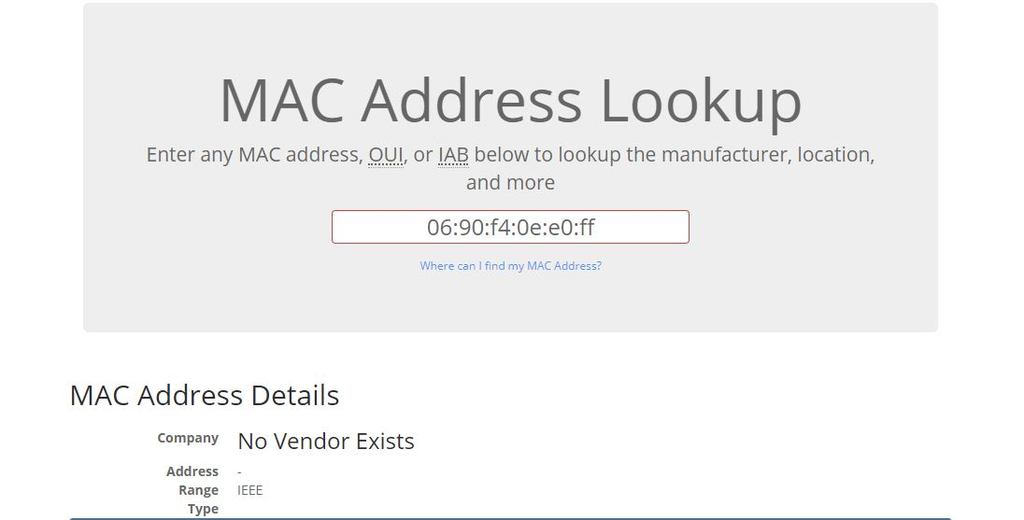

As such there is no other information in the packets which allow us to see which vendor is responsible for which packet.

[3. Macaddress.io. (n.d.) What are a universal address and a local administered address? Retrieved October 5, 2020 from https://macaddress.io/faq/what-are-a-universal-address-and-a-local-administered-address](https://macaddress.io/faq/what-are-a-universal-address-and-a-local-administered-address)

### Data peak rate of the attack (Q14)

In order to find the data peak rate of the attack we group the total packet length that is sent per second and plot these values. The length in the dataset represents the amount of bytes. Internet speeds are often denoted in Megabits/second. We can convert the length in bytes to length in bits by multiplying by 8. 1 Megabit is 1000000 bits. Therefore the length in bytes to Megabits is achieved by multiplying by 8 and then dividing by 1000000.

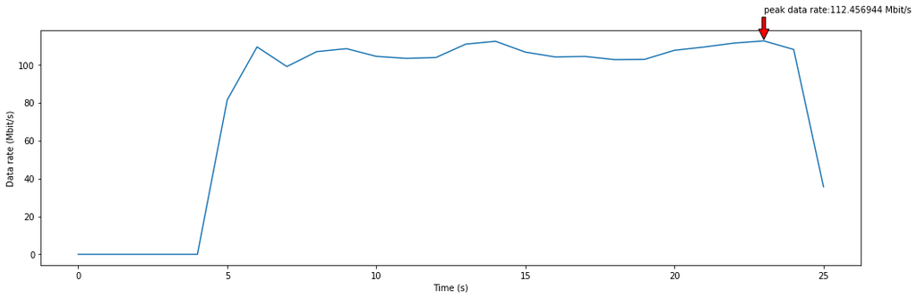

```python
last_second = math.ceil(traffic_to_victim_filtered['Time'].max())
cut = pd.cut(traffic_to_victim_filtered['Time'], bins=list(np.arange(0.0, last_second + 1.0, 1.0)), labels=range(last_second) )
datarates = traffic_to_victim_filtered.groupby(cut)['Length'].sum()
datarates = (datarates*8)/1000000
plot = datarates.plot(figsize=(17, 5), ylabel="Data rate (Mbit/s)", xlabel="Time (s)")
maxz= datarates.sort_values(ascending=False)[:1]

plot.annotate('peak data rate:{} Mbit/s'.format(maxz[0]), xy=(maxz.index[0], maxz[0]), xytext=(maxz.index[0],  maxz[0]+15), arrowprops=dict(facecolor='red', shrink=0.05),)
```

As we can see above, the peak data rate is 112.5 Mbit/s. This is an interesting number, since it is just slightly above 100 Mbit/s, the maximum older internet hardware (before Gigabit was standard) was able to process. It might be the case that the victim still used old internet hardware and therefore this attack was able to saturate the entire network bandwidth.

### Distribution/frequency of DNS flags involved in the attack (Q15)

The question asks for the distribution/frequency of TCP flags in the attack, however the attack is a DNS based attack which does not use TCP. Therefore we assume this must have been a typo and the DNS flags were meant. We can plot the different kinds of DNS flags involved as follows:

```
0x8180    92988
0x8380    26795
0x8182      348
0x8102       18
Name: Flags, dtype: int64
```

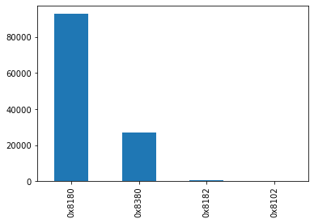

```python
distribution = traffic_to_victim_filtered['Flags'].value_counts()
distribution.plot(kind='bar')
distribution
```

The meaning of these flags are not immediately clear from it's hexadecimal value. In order to understand what these flags mean, we convert them to their binary counterpart. We can then use section 4.1.1. of [RFC1035](https://tools.ietf.org/html/rfc1035) to determine the exact meaning.

#### 0x8180 (Response with recursive query, no errors)

```python
"{0:08b}".format(int("0x8180", 16))
```

```
'1000000110000000'
```

**1**: First bit indicates that this message is a response and not a query.

**0000**: Four bit field indicating the opcode. In this case it is a standard query.

**0**: Bit indicating whether the answer is an authoritive answer. This server is not an authority for the domain name in the question section.

**0**: The message is not truncated

**1**: Directs the server to pursue the query recursively. This is copied from the query to the response message.

**1**: Indicates that recursive query support is available on the server.

**0**: The RFC has three bits which are reserved for future use, must be zero. However two of these bits are currently in use (according to wireshark)

**0**: DNSSEC only, the answer is not authenticated by the server

**0**: DNSSEC do check if the data is authenticated at the receiving server

**0000**: Reply code indicating that no errors occurred.

#### 0x8380 (Like 0x8180, but now a truncated message)

```python
"{0:08b}".format(int("0x8380", 16))
```

```
'1000001110000000'
```

**1**: First bit indicates that this message is a response and not a query.

**0000**: Four bit field indicating the opcode. In this case it is a standard query.

**0**: Bit indicating whether the answer is an authoritive answer. This server is not an authority for the domain name in the question section.

**1**: The message is truncated

**1**: Directs the server to pursue the query recursively. This is copied from the query to the response message.

**1**: Indicates that recursive query support is available on the server.

**0**: The RFC has three bits which are reserved for future use, must be zero. However two of these bits are currently in use (according to wireshark)

**0**: DNSSEC only, the answer is not authenticated by the server

**0**: DNSSEC do check if the data is authenticated at the receiving server

**0000**: Reply code indicating that no errors occurred.

#### 0x8182 (Like 0x8180, but now a server failure occurred)

```python
"{0:08b}".format(int("0x8182", 16))
```

```
'1000000110000010'
```

**1**: First bit indicates that this message is a response and not a query.

**0000**: Four bit field indicating the opcode. In this case it is a standard query.

**0**: Bit indicating whether the answer is an authoritive answer. This server is not an authority for the domain name in the question section.

**0**: The message is not truncated

**1**: Directs the server to pursue the query recursively. This is copied from the query to the response message.

**1**: Indicates that recursive query support is available on the server.

**0**: The RFC has three bits which are reserved for future use, must be zero. However two of these bits are currently in use (according to wireshark)

**0**: DNSSEC only, the answer is not authenticated by the server

**0**: DNSSEC do check if the data is authenticated at the receiving server

**0010**: Reply code indicating that a server failure occurred: "The name server was unable to process this query due to a problem with the name server."

#### 0x8102 (Like 0x8182, but now server does not support recursion)

```python
"{0:08b}".format(int("0x8102", 16))
```

```
'1000000100000010'
```

**1**: First bit indicates that this message is a response and not a query.

**0000**: Four bit field indicating the opcode. In this case it is a standard query.

**0**: Bit indicating whether the answer is an authoritive answer. This server is not an authority for the domain name in the question section.

**0**: The message is not truncated

**1**: Directs the server to pursue the query recursively. This is copied from the query to the response message.

**0**: Indicates that recursive query support is not available on the server.

**0**: The RFC has three bits which are reserved for future use, must be zero. However two of these bits are currently in use (according to wireshark)

**0**: DNSSEC only, the answer is not authenticated by the server

**0**: DNSSEC do check if the data is authenticated at the receiving server

**0010**: Reply code indicating that a server failure occurred: "The name server was unable to process this query due to a problem with the name server."

Using the distribution of the DNS flags in the attack trace, we can see that the majority of packets are messages that form a response to a recursive query. These packets are the majority of the time non-truncated, but about a quarter (total packets = 92988 + 26795 + 348 + 18 = 120149, truncated = 26795, 26795/120149=0,22) are truncated. A small amount of queries could not be executed due to a server failure. We were wondering what such a server failure could be, e.g. did the attacker select DNS servers that are not able to perform DNS amplification, or did the servers use rate limiting, did the DNS servers themselves go down?

### Reason DNS servers errored

We analyze this by selecting an IP Address that sent the most packets with the 0x8182 flag. This indicates that a server error occurred.

```python
traffic_to_victim_filtered[traffic_to_victim_filtered.Flags == "0x8182"].groupby("Source").count()["No."].sort_values(ascending=False)[:1]
```

```
Source
59.46.49.50    154
Name: No., dtype: int64
```

We now look at the domain names that were requested from this DNS server and group these based on the flags the response message contained.

```python
traffic_to_victim_filtered[traffic_to_victim_filtered.Source == "59.46.49.50"].groupby(["Name", "Flags"]).count()["No."]
```

```
Name          Flags
bls.gov       0x8180    273
irs.gov       0x8180    262
isc.org       0x8180    401
nlhosting.nl  0x8180    378
sandia.gov    0x8180    363
verisign.com  0x8180    147
              0x8182    154
Name: No., dtype: int64
```

As we can see above, the errors only occurred for one domain: versign.com.

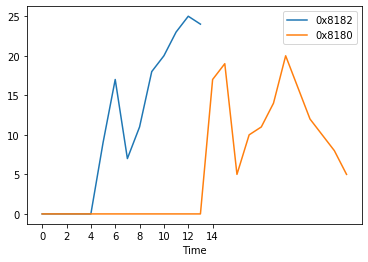

```python
verisign_traffic = traffic_to_victim_filtered[(traffic_to_victim_filtered.Source == "59.46.49.50") & (traffic_to_victim_filtered.Name == "verisign.com")]
fig, ax = plt.subplots()

for flag in verisign_traffic.Flags.unique():
    selected = verisign_traffic[verisign_traffic.Flags == flag]
    last_second = math.ceil(selected['Time'].max())
    cut = selected.groupby(pd.cut(selected['Time'], bins=list(np.arange(0.0, last_second + 1.0, 1.0)), labels=range(last_second)))
    cut.count()["No."].plot(ax=ax, label=flag)

ax.legend()
```

We can see that the errors only happen at the beginning of the attack trace, not at the end. Eliminating the possibility that these errors are due to rate limiting. What did cause the error is unknown. It might be that the DNS record was unknown for the DNS server and a lookup failed. After a while this lookup succeeded and the DNS requests after that used the cached values for verisign.com (which thus gave no errors).

### Distribution of packet length (Q16)

As you can see in the histogram below, there are quite a lot of packets that are smaller than 500 bytes. But, you also see that there are even more packets that are between 2500 and 3200. And there are no packets that are roughly 1500 bytes long, which is interesting. So the length of the packets fluctuates.

We also wanted to know if each DNS server sends only packets of roughly the same length (which would mean the attackers would have used only a few domains for that DNS server every time). This does not appear to be the case as you can see in the second histogram. So it appears a couple of DNS records of different sizes have been requested per DNS server.

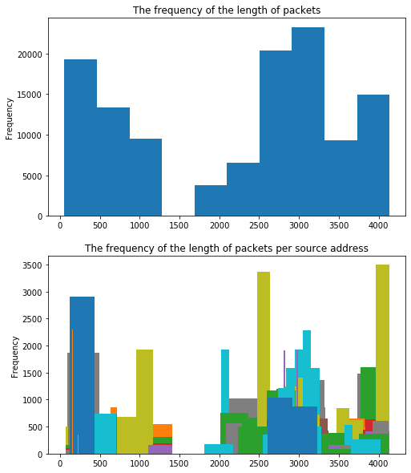

```python
fig, axes = plt.subplots(nrows=2, ncols=1, figsize=(8,10))

plt.subplot(2,1,1)
traffic_to_victim['Length'].plot(kind='hist', title="The frequency of the length of packets", xlabel="Length of packet (Bytes)")

plt.subplot(2,1,2)
traffic_to_victim.groupby(by='Source')['Length'].plot(kind="hist", title="The frequency of the length of packets per source address", xlabel="Packet length (Bytes)")

None
```

### Amplification Factor

By plotting the domain names requested against the frequency of the responses for that domain name and the packet length of such a response, we can find out what the most often occurring largest DNS response is.

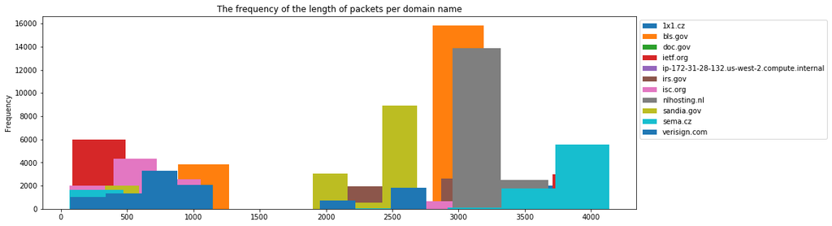

```python
ax = traffic_to_victim.groupby(by='Name')['Length'].plot(kind="hist", title="The frequency of the length of packets per domain name", xlabel="Packet length (Bytes)", figsize=(15,5))
plt.legend(bbox_to_anchor=(1, 1), loc='upper left')
```

This appears to be sema.cz. Since the trace was made (2014) and now (2020), sema.cz seems to have disappeared. However we can still make an educated guess on the amplification that could have been achieved with this domain name. By creating a DNS request for sema.cz on Linux using `dig any sema.cz` and capturing that request, we can see how large such a request would have been.

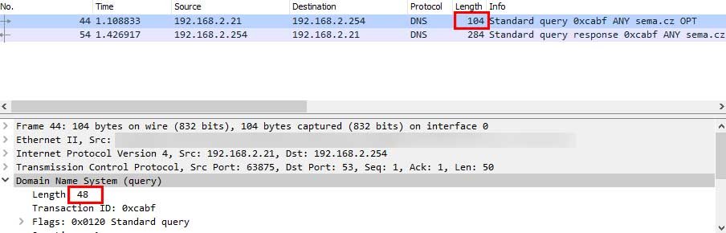

.

The actual DNS query has a length of 48, however the packet length is 104. Since our capture also has the packet length and not the DNS response length, we will stay consistent and use the packet length in our calculation. The average DNS response packet size of a succesfull query is:

```python
sema_cz_succesful = traffic_to_victim[(traffic_to_victim.Length > 1500) & (traffic_to_victim.Name == "sema.cz")]
print("There are {} packets fitting this criteria".format(sema_cz_succesful.shape[0]))
print("Which created a summed packet length of {} bytes".format(sema_cz_succesful["Length"].sum()))
print("This is on average a packet length of {} bytes".format(sema_cz_succesful["Length"].sum()/sema_cz_succesful.shape[0]))
```

```
There are 7511 packets fitting this criteria
Which created a summed packet length of 29566299 bytes
This is on average a packet length of 3936.3998136067103 bytes
```

This means the amplification factor is on average for succesful queries about sema.cz: 3936/104=37,846

## Conclusions and Reflections

Through analyzing the majority of packets in the trace, and after that analyzing specific details about certain packets, we have found out that this is a DDoS attack on a webserver. This DDoS attack is facilitated by leveraging DNS Amplification, in which many DNS servers were used (up to 79). However, the amount of packet and packet length sent by each DNS server varies. This is partly due to certain DNS servers giving errors as responses to queries, instead of actual query responses. This made the attack less succesful, since these error responses are shorter than the wanted responses, lowering the amplification factor. The amplification factor of some DNS queries used in this attack are in a best case scenario around 38. This means that for every byte sent by the attacker, the victim can receive 38 bytes. This can dramatically increase the peak data rates of the attack. In this attack the peak data rate that was achieved exceeds a bit above 112 Mbits per second. This is an interesting observation since many computers nowadays are equipped with gigabit ethernet. This leads to many explanations about if the availability of the website was affected and if so, why it was affected. E.g. this can be a case of old equipment (10/100 network) was used, the network bandwidth of the server being lower than 110Mb/s, or the DNS responses overwhelming the CPU or webserver program running on port 80. It is not certain if the server would have crashed because of this data rate specifically. It may well have been possible that the website that the webserver was serving was slow during the attack, but still reachable.

In order to prevent such an attack, one could for instance install a firewall that blocks any incoming DNS responses that are requesting domainnames such as the ones in this attack. These domainnames are often custom made for attacks, to have a response size as large as possible. In this specific example a webserver was targeted. It is not logical that a webserver will receive traffic from port 53 (the port used by DNS), since the webserver usually receives connections from internet browsers. Internet browsers use so called 'unregistered' or 'dynamic' port numbers, these are the port numbers above and including 1024. The DNS port 53 is in the registered range, and will most often not be used as a source port by a legitimate user using a webbrowser. [1] Therefore any source ports under 1024 could be blocked in a firewall from accessing the server. However even with these efforts, it is still possible to completely saturate an internet connection or overwhelm the firewall. In that case the best option is to use professional services, such as the National Scrubbing Center against DDoS Attacks, to scrub the traffic.

The owners of the DNS servers can also put in some effort to make it harder to use their DNS servers for DNS amplification attacks. They can put restrictions on the maximum packet response size (truncation), but can also disable recursive querying (allowing only one specific line of the DNS record to be queried, instead of the entire DNS record). [2] A final measure is the Response Rate Limiting of DNS requests. This allows only a certain amount of DNS requests per IP address per specific timeframe, to prevent that a large amount of DNS query responses can be created. Such a measure can have a large impact on users. Think about many users in a corporate network trying to make a DNS query for Google.com, having to deal with such a rate limit. There are methods to circumvent this that can be implemented by the network administrators of the corporate network, but efforts can also be made on the side of the DNS provider. Such an effort would be only rate limiting the DNS queries for newly registered domains.

This analysis allowed us an exclusive opportunity to analyse actual DDoS traffic in order to answer our questions on how this attack took place and how such an attack could be prevented.

[1. Wikipedia. (2020, September 10). Registered Port. Retrieved October 6, 2020 from https://en.wikipedia.org/wiki/Registered_port.](https://en.wikipedia.org/wiki/Registered_port)

[2. Akamai. (2015, June 12). DNS AMPLIFICATION ATTACKS AND TRUNCATED RESPONSES. Retrieved October 6, 2020 from https://blogs.akamai.com/2015/06/dns-amplification-attacks-and-truncated-responses.html](https://blogs.akamai.com/2015/06/dns-amplification-attacks-and-truncated-responses.html)